# An Introduction to Bayesian Inference using R Interfaces to Stan, Part II

July 30, 2016

## Writing Stan Programs

## Workflow for Stan via the **rstan** R Pakcage

1. You write the program in a (text) .stan file in the Stan language
2. Stan's parser, `stanc`, does two things:
   - checks that program is syntactically valid and tells you if not
   - writes a conceptually equivalent C++ source file to disk
3. C++ compiler creates a binary file from the C++ source
4. C++ is used due to operator overloading and templating
   - C++ also facilitates autodifferentiation
5. You execute the binary from R (can be concurrent with 2 – 4)
6. You analyze the resulting draws from the posterior

## Primitive Object Types in Stan

- In Stan / C++, variables must first be declared with types
- In Stan / C++, statements are terminated with semi-colons
- Primitive scalar declarations: `real x;` or `int K;`
  - Unknowns cannot be int. No derivatives and hence no HMC
  - Can condition on integer data. No derivatives are needed
- Real declarations: `vector[K] z;`, `row_vector[K] zt;`, `matrix[N,K] X;`
- Arrays are just holders of any other *homogenous* objects, like an R list where are elements are restricted to be the same type and shape
- Vectors and matrices cannot contain *genuinely* integer data so use integer array declarations: `int y[N];` or `int Y[N,P]`;

## Builtin Functions in Stan

- **rstan** has a function called `lookup`
- Input the name of an R functionto find an analagous Stan function
- Input a regular expression to find all matching Stan functions

```r
suppressPackageStartupMessages(library(rstan))
lookup("besselK")
```

```
##                    StanFunction       Arguments ReturnType Page
## 290 modified_bessel_second_kind (int v, real z)       real  342
```

## Optional `functions` Block of a Stan Program

- Stan permits users to define and use their own functions
- If used, must be defined in a leading `functions` block
- Can only validate constraints inside user-defined functions
- Very useful for several reasons
  1. Easier to reuse across different .stan programs
  2. Makes subsequent chunks of code more readable
  3. Enables likelihoods with Ordinary Differential Equations
  4. Can be exported to R via `expose_stan_functions`
- All functions, whether user-defined or build-in, must be called by argument position rather than by argument name, and there are no default arguments
- See cumprod.stan file

## Constrained Object Declarations in Stan

- Any primitive object can have lower and / or upper bounds if declared in the `data`, `transformed data`, `parameters`, or `transformed parameters` blocks
- `int<lower=1> K; real<lower=-1,upper=1> rho;`
- `vector<lower=0>[K] alpha;` and similarly for a `matrix`
- Alternatively, a `vector` can be specialized as
  1. `unit_vector[K] x;` implies \(\sum_{k=1}^K{x_k^2} = 1\)
  2. `simplex[K] x;` implies \(x_k \geq 0 \forall k\) and \(\sum_{k=1}^K{x_k} = 1\)
  3. `ordered[K] x;` implies \(x_i \leq x_j \forall i<j\)
  4. `positive_ordered[K] x;` implies also \(0 \leq x_1\)
- Alternatively, a `matrix` can be specialized as
  1. `cov_matrix[K] Sigma` or better `cholesky_factor_cov[K,K] L;`
  2. `corr_matrix[K] Lambda` or better `cholesky_factor_corr[K] L;`

## Required `data` Block of a Stan Program

- Contains declarations for *everything* being conditioned on in Bayes Rule
- Each such object needs to be passed from R as a named list
- Can have comments in C++ style (`// comment` or `/* comment */`)
- Whitespace is essentially irrelevant

  ```
  data {
    int<lower=1> N; // number of observations
    int<lower=1> K; // number of predictors
    matrix[N, K] X; // design matrix
    vector[N]    y; // outcomes
    real<lower=0> prior_mean; // hyperparameter
  }
  ```

## Optional `transformed data` Block

- Is executed only once before the iterations start
- Used to calculate needed deterministic functions of objects in the `data` block
- Can use it to check that data was passed correctly from R
- All declarations must come directly after the opening {

  ```
  transformed data {
    vector[N] log_y;
    log_y = log(y);
  }
  ```

## Required `parameters` Block of a Stan Program

- Declare everything whose posterior distribution is sought
- Cannot declare `int` parameters
- Cannot do assignments within the `parameters` block
- *Must* specify the sample space of the parameters but lower and upper bounds are implicitly \(\pm\infty\) if unspecified

  ```
  parameters {
    vector[K] beta;
    real<lower=0> sigma_unscaled; // Jacobian handled automatically here
  }
  ```

## Optional `transformed parameters` Block

- Like `transformed data` but involves objects declared in the `parameters` block and is evaluated each leapfrog step
- Constraints are validated and draws are stored

  ```
  transformed parameters {
    real<lower=0> sigma;
    sigma = sigma_unscaled * prior_mean;
  }
  ```

## Required `model` Block of a Stan Program

- Builds up a evaluation of the log-kernel function with the `target` keyword
- Can declare local objects at the top of the `model` block and then assign to them but draws are not stored

  ```
  model {
    vector[N] eta;
    eta = X * beta;
    target += normal_lpdf(log_y | eta, sigma);      // likelihood of log(y)
    target += normal_lpdf(beta | 0, 5);             // prior for each beta_k
    target += exponential_lpdf(sigma_unscaled | 1); // prior for sigma_unscaled
  }
  ```

- Can increment `target` with user-defined functions or arbitrary expressions

## Optional `generated quantities` Block

- Only evaluated once per iteration
- Useful to declare and define objects of interest that do not go into the likelihood function
- Can reference any object declared in `data`, `transformed data`, `parameters`, or `transformed parameters` blocks
- Can use pseduo-random number generation

  ```
  generated quantities {
    vector[N] y_rep; // posterior beliefs about each y[n]
    for (n in 1:N) y_rep[n] = normal_rng(X[n,] * beta, sigma);
  }
  ```

## Calling a Stan Program

```r
state.x77 <- within(as.data.frame(state.x77), { # choose reasonable units
  Density <- Population / Area
  Income <- Income / 1000
  Frost <- Frost / 100
})
X <- model.matrix(Murder ~ Density + Income + Illiteracy + Frost, data = state.x77)
y <- state.x77$Murder
data_block <- list(N = nrow(X), K = ncol(X), X = X, y = y, prior_mean = 5)
options(mc.cores = parallel::detectCores())
post <- stan("regression.stan", data = data_block)
```

## Results

```r
print(post, pars = 'y_rep', include = FALSE, digits = 2, probs = c(.25, .75))
```

```
## Inference for Stan model: regression.
## 4 chains, each with iter=2000; warmup=1000; thin=1;
## post-warmup draws per chain=1000, total post-warmup draws=4000.
##
##                  mean se_mean   sd    25%    75% n_eff Rhat
## beta[1]          0.75    0.02 0.74   0.26   1.22  1476    1
## beta[2]         -0.60    0.01 0.33  -0.83  -0.39  2129    1
## beta[3]          0.17    0.00 0.13   0.08   0.26  1666    1
## beta[4]          0.57    0.00 0.16   0.46   0.68  1728    1
## beta[5]         -0.23    0.00 0.18  -0.35  -0.11  2090    1
## sigma_unscaled   0.09    0.00 0.01   0.09   0.10  2368    1
## sigma            0.47    0.00 0.05   0.44   0.51  2368    1
## lp__           -47.99    0.05 1.82 -48.95 -46.64  1315    1
##
## Samples were drawn using NUTS(diag_e) at Sat Jul 30 13:28:10 2016.
## For each parameter, n_eff is a crude measure of effective sample size,
## and Rhat is the potential scale reduction factor on split chains (at
## convergence, Rhat=1).
```

## Diagnostics

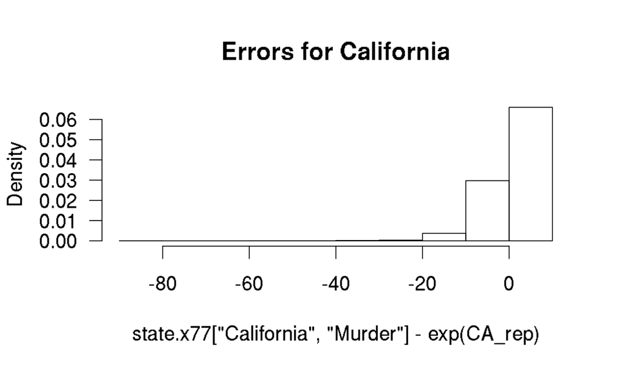

```r
CA_rep <- extract(post, pars = 'y_rep')[[1]][,which(rownames(state.x77) == "California")]
hist(state.x77["California", "Murder"] - exp(CA_rep), prob = TRUE,
     main = "Errors for California", las = 1)
```

## Hierarchical Models

## Bayesian Perspective on Hierarchical Models

- Hierchical models are essentially models with interaction terms between predictors and group-indicators with the additional provisions that:
  - Group deviations are from a common mean rather than a baseline
  - Include distributional assumptions for how the groups deviate
- Suppose there are \(J\) groups and \(N_j\) observations in the \(j\)-th group and \[y_{ij} \thicksim \mathcal{N}\left(\mu_{ij},\sigma\right) \forall i,j\] \[\mu_{ij} = \left(\alpha + a_j\right) + \left(\beta + b_j\right)x_{ij} = \alpha + \beta x_{ij} + a_j + b_j x_{ij} \forall i,j\] \[\begin{bmatrix}a_j\\ b_j \end{bmatrix} \thicksim \mathcal{N}_{2}\left(\begin{bmatrix} 0 \\ 0 \end{bmatrix}, \begin{bmatrix} \sigma_a^2 & \rho \sigma_a \sigma_b \\ \rho \sigma_a \sigma_b & \sigma_b^2 \end{bmatrix}\right) \forall j\]
- Bayesians put priors on the *common* parameters \(\sigma\), \(\alpha\), \(\beta\), \(\rho\), \(\sigma_a\), and \(\sigma_b\)

## Frequentist Perspective on Hierarchical Models

- For frequentists, \(a_j + b_j x_{ij}\) is part of the error term; thus
  - Observations within group \(j\) aren't conditionally independent given \(\alpha\) & \(\beta\)
  - Frequentists are willing to make distributional assumptions about \(a_j\) and \(b_j\) (invariably bivariate normal). Let \(\boldsymbol{\Sigma} = \begin{bmatrix} \sigma_a^2 & \rho \sigma_a \sigma_b \\ \rho \sigma_a \sigma_b & \sigma_b^2 \end{bmatrix}\) and

  \[z_{ij} = \int\limits _{-\infty}^{\infty} \int\limits _{-\infty}^{\infty} { \frac{1}{\sigma \sqrt{2 \pi}}{ e^{-0.5 \left(\frac{y_{ij} - \alpha - \beta x_{ij} - a_j - b_j x_{ij}}{\sigma} \right)^2}} \frac{1}{\left|\boldsymbol{\Sigma}\right|}e^{-0.5 \begin{bmatrix} a_j \\ b_j \end{bmatrix}^\top \boldsymbol{\Sigma}^{-1} \begin{bmatrix} a_j \\ b_j \end{bmatrix}} \ da_j db_j}\]
- This particular integral happens to have a closed-form solution and one can choose \(\sigma\), \(\alpha\), \(\beta\), \(\rho\), \(\sigma_a\), and \(\sigma_b\) to maximize \(\sum_{j=1}^J \sum_{i=1}^{N_j} \ln z_{ij}\)
- But maximum likelihood is not a great estimator here so people penalize

## Limitations of Frequentist Perspective

- For frequentists, \(a_j\) and \(b_j\) are not parameters and thus cannot be *estimated*
- \(a_j\) and \(b_j\) can be *predicted* from group \(j\)'s residuals implied by \(\widehat{\alpha}\) and \(\widehat{\beta}\)
- Since \(a_j\) and \(b_j\) are not *estimated*, you cannot construct standard errors
- Thus, you cannot make frequentist inferences about \(a_j\) and / or \(b_j\)
- You can conceptualize standard errors for the estimator of the common parameters \(\sigma\), \(\alpha\), \(\beta\), \(\rho\), \(\sigma_a\), and \(\sigma_b\) but they are hard to calculate unless you treat the predictions of \(a_j\) and \(b_j\) as given
- To obtain a closed-form likelihood function to maximize, you have to assume normality both for the outcome (conditional on \(x_{ij}\)) and for \(a_j, b_j\). Otherwise, you get all of the computational difficulty with intractable integrals that Bayesians avoid with MCMC and none of the benefit in interpretation.
- The optimization process is not nearly as routine as it is for flat GLMs, and you often get corner solutions where \(\widehat{\boldsymbol{\Sigma}}\) is not positive definite

## The `stan_glmer` Function

- The `[g]lmer` functions in the **lme4** R package are very popular because people want to quickly estimate hierarchical models with a convenient syntax and interpret the results as if they were Bayesian
- But you can slowly estimate hierarchical models using the same convenient syntax by using the `stan_glmer` function in the **rstanarm** R package and interpret the results in a genuinely Bayesian fashion
- Eric will show an example of this

## Summary

- You can write almost any posterior log-kernel (whose parameters are continuous) in the Stan language
- Whether Stan samples efficiently depends on how numerically stable your Stan program is
  - But Stan will have no problem with a multivariate normal
  - Stan has no problem with a lot of non-normal posteriors
  - If Stan has problems, you can usually work around them
  - If you cannot get around those problems, other software will usually suffer from them too without being as easy to diagnose
- Easy to include particular Stan program(s) in a package like **rstanarm** does; see the `rstan.package.skeleton` function in the **rstan** package